Theobio main page

# Ontario COVID-19 forecasts

[#MacTheobio COVID Modelling Group](https://mac-theobio.github.io/covid-19/)

Irena Papst ([@irenapapst](https://twitter.com/irenapapst)), Ben Bolker ([@bolkerb](https://twitter.com/bolkerb)), Jonathan Dushoff ([@jd_mathbio](https://twitter.com/jd_mathbio)), David Earn ([@DavidJDEarn](https://twitter.com/davidjdearn))

McMaster University, Hamilton, Ontario, Canada, L8S 4K1

Forecast date: 17 Oct 2021

*Post last updated: 24 Oct 2021*

# Context

Every three weeks, [our group](https://mac-theobio.github.io/covid-19/) provides COVID-19 infection report forecasts for the province of Ontario to the [Ontario Modelling Consensus Table](https://covid19-sciencetable.ca/our-partners/) (MCT), a partner of the [Ontario Science Advisory Table](https://covid19-sciencetable.ca) (SAT), which presents this information to the Health Coordination Table of the Ontario Ministry of Health.[^1] Other modelling groups also provide forecasts to the MCT. After reviewing all forecasts provided, the MCT provides consensus projections to the SAT.

Our forecasts are based on a [compartmental epidemic model](https://en.wikipedia.org/wiki/Compartmental_models_in_epidemiology) implemented in our publicly available [`McMasterPandemic`](https://github.com/bbolker/McMasterPandemic) R package, and involve statistical fits to [Ontario’s latest infection report data](https://covid-19.ontario.ca/data).

# Forecast overview

The forecast presented here was made on **17 Oct 2021** and was submitted to the MCT for inclusion in the SAT’s [update on COVID-19 projections](https://covid19-sciencetable.ca/sciencebrief/update-on-covid-19-projections-12/), released on 22 Oct 2021.

This set of projections explores **the *potential* effect of lifting capacity limits on select large-scale venues where proof of vaccination is required**. While these capacity limits were indeed lifted on 9 Oct, it is too soon to infer any effect that this event may have had on transmission from the infection report data. We describe the transmission scenarios we considered in detail below.

We have updated, and will continue to update, this post in order to show the [latest infection reports](https://covid-19.ontario.ca/data), but the forecasts themselves have not, and will not, be modified after the forecast date.

# Forecast results

The following figure gives the infection report forecasts (curves), with 95% confidence intervals as bands around each forecast curve. Observed infection reports to which the model was fit are plotted with **solid points**, while observations after the fact are included as **hollow points**.

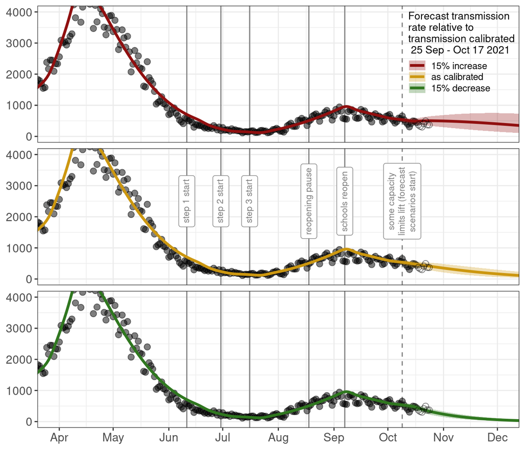

As the province continues to reopen and cooler weather causes more social interactions to occur indoors, there is a risk for transmission to increase from its current low level. The extent to which vaccination, masking, and other measures counterbalance this risk remains to be seen. Our forecasts suggest that **the province can currently tolerate a small increase to transmission** without raising infection reports substantially.

# Forecast and model details

## Transmission

We assume that the transmission rate is piecewise constant through the fit period, selecting re-estimation dates for this rate based on large-scale changes in public health measures (*e.g.* a stay-at-home order or a major reopening step) or when it appears individual behaviour may be changing. By assuming that the transmission rate is constant between re-estimation dates, we capture the average effect of any changes in transmission over the entire period between these dates.

Our forecast scenarios focus on exploring the potential effect of **lifting capacity limits in some large-scale venues where proof of vaccination is required**, which occured on 9 Oct 2021. Since only eight days had elapsed since this policy change and when we calibrated our model on 17 Oct 2021 (the **model calibration date**), we were not yet able to robustly estimate the degree to which this change affected transmission: few transmission events that occurred after 9 Oct 2021 would have led to reported cases by 17 Oct 2021.

1. a 15% increase in transmission;
2. as calibrated, *i.e.* a status quo forecast;
3. a 15% decrease in transmission.

Due to the delay in infection reports, differences between the forecast scenarios in the plot above do not become apparent until about two weeks after the forecast scenario start date.

## Variants

We model the Delta variant as taking over Alpha through the fit period, under the assumption that Delta is **50% more transmissible** than Alpha, based on variant surveillence conducted by Public Health Ontario. We continue to model any further increases to Delta frequency through the forecast period, though these changes are minimal as virtually all infections in the province have been caused by Delta since early August (see Figure 5 in the [Public Health Ontario Daily Epidemiologic Report](https://www.publichealthontario.ca/-/media/documents/ncov/epi/covid-19-daily-epi-summary-report.pdf?sc_lang=en)).

## Vaccination

For vaccination, we use the reported number of first and second doses administered each day in the fit period. In the forecast period, we assume that **first doses** saturate to **90%** of the eligible population (aged 12+ in 2021) and **second doses** saturate to **85%**. (As of 17 Oct 2021, 87% of eligible Ontario residents had received at least one dose, while 83% had received two doses, according to [COVID-19 Tracker Canada](https://covid19tracker.ca/provincevac.html?p=ON).)

The per-dose infection-blocking vaccine effectivenesses differ between Alpha and Delta, so we adjust them in the model depending on the daily estimated frequency of the Delta variant. The baseline effectivenesses used are:

|  | First dose | Second dose |
| --- | --- | --- |
| Alpha | 60% | 90% |
| Delta | 30% | 80% |

The vaccination model also includes the following assumptions:

1. **Vaccine-derived immunity** takes an average of **14 days** to develop after a dose is administered.
2. If a vaccinated individual is infected, their **probability of having a less-transmissible, asymptomatic infection** increases with each dose (20% for the unvaccinated, 60% for those protected by one dose, and 90% for those protected by two doses).
3. Vaccines are administered **at random** in the population (we do not explicitly account for age or other characteristics of individuals).

Related post: [Ontario COVID-19 forecasts, 20 Sep 2021](https://mac-theobio.github.io/forecasts/outputs/McMasterOntarioForecastsBlog2021-09-20)

[Back to the MacTheobio COVID Modelling Group page](https://mac-theobio.github.io/covid-19/)

[^1]: This report has been written independently of the Ontario Modelling Consensus Table, the Ontario Science Advisory Table, and the Health Coordination Table. The views expressed in this report are solely the authors’.